# Running large databases: PIM

# Introduction

In this report, we try to fit PIM models when $N$ is large. As the estimation procecures uses the set of *pseudo-observations*, the computation time increases exponentially with $n$: $O(n^2)$.

# Data generation

We will generate data according to the normal linear model: $Y_i = \alpha X_i + \varepsilon_i$ with $i=1,...n$. Also, $\varepsilon_i|X_i$ are IID and $N(0, \sigma^2_\varepsilon(X_i))$. The predictor takes values uniformly within $[0.1,u]$ where $u = 1$. For instance, take $\alpha = 5$. Then generating data and fitting the PIM model in R is done through:

```r
library(pim)
library(nleqslv)
library(data.table)
library(ggplot2)
```

```r
# Parameters
n <- 50
u <- 1
alpha <- 5
sigma <- 1
trueBeta <- alpha/(sqrt(2) * sigma)

# Generate predictor
X <- runif(n = n, min = 0.1, max = u)
# Generate data
Y <- alpha*X + rnorm(n = n, mean = 0, sd = sigma)

# PIM package beta parameter
BETAvalue <- try(pim(formula = Y ~ X, link = 'probit', model = 'difference')@coef, silent = TRUE)
data.frame(BETAvalue,trueBeta)
```

```
  BETAvalue trueBeta
X  2.692332 3.535534
```

# Increasing N

We take the code from above, and run this while increasing $N$ initially from $10$ to $25.000$.

## Locally

First, we test this locally. The vector $N$ is given by:

```r
n <- round(seq(10,25000,length.out = 25), 0)
```

The estimated beta coefficients and time needed to estimate the model for each sample size $N$ are stored in a text file.

```r
# Text files: time is measured in minutes
estimBeta <- fread('/Users/hanbossier/Dropbox/Mastat/Thesis/ResultsTimeNeeded/beta_501.txt', data.table = FALSE, col.names = 'EstimatedBeta')
TimeNeeded <- fread('/Users/hanbossier/Dropbox/Mastat/Thesis/ResultsTimeNeeded/time_501.txt', data.table = FALSE, col.names = 'TimeInMin')
# Overview
local <- data.frame(EstimatedBeta = estimBeta, TrueBeta = trueBeta, SampleSize = n, TimeInMin = TimeNeeded);local
```

```
   EstimatedBeta TrueBeta SampleSize    TimeInMin
1       3.710759 3.535534         10 2.161145e-04
2       3.284670 3.535534       1051 2.462467e-02
3       3.525353 3.535534       2092 8.193035e-02
4       3.523066 3.535534       3134 1.468487e-01
5       3.565256 3.535534       4175 2.352749e-01
6       3.618371 3.535534       5216 3.785054e-01
7       3.559371 3.535534       6258 5.913721e-01
8       3.522990 3.535534       7299 8.094707e-01
9       3.456785 3.535534       8340 1.077774e+00
10      3.566096 3.535534       9381 1.357088e+00
11      3.537316 3.535534      10422 1.733767e+00
12      3.520023 3.535534      11464 2.024379e+00
13      3.531523 3.535534      12505 2.585303e+00
14      3.550803 3.535534      13546 3.073942e+00
15      3.499380 3.535534      14588 3.837159e+00
16      3.525123 3.535534      15629 5.019652e+00
17      3.519586 3.535534      16670 6.213987e+00
18      3.507788 3.535534      17711 9.291136e+00
19      3.533566 3.535534      18752 1.170329e+01
20      3.555743 3.535534      19794 1.623747e+01
21      3.571614 3.535534      20835 2.271294e+01
22      3.527799 3.535534      21876 2.695617e+01
23      3.537034 3.535534      22918 3.378866e+01
24      3.502156 3.535534      23959 4.655588e+01
25      3.554781 3.535534      25000 5.753793e+01
```

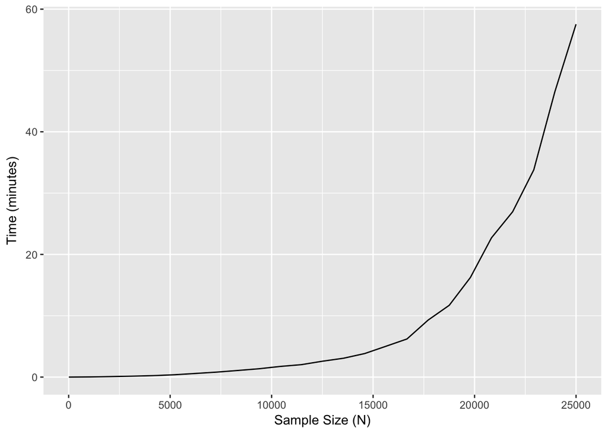

```r
# Plot
ggplot(local, aes(x = SampleSize, y = TimeInMin)) + geom_line() +
    scale_x_continuous(name = "Sample Size (N)") + scale_y_continuous(name = "Time (minutes)")
```

## HPC

We execute the same code on the HPC infrastructure of UGent and iterated for $K = 500$ times. The results are stored externaly in text files caled *beta_N_n_K_k.txt* and *time_N_n_K_k.txt* in which small *n* and small *k* represent the sample size and iteration respectively.

```r
# Data directory
dataWD <- '/Volumes/2_TB_WD_Elements_10B8_Han/PhD/BigDataPIM/TimeNeeded/output/separate'
# Number of simulations
nsim <- 500
betavalues <- array(NA, dim = c(length(n), nsim))
recordedTime <- array(NA, dim = c(length(n), nsim))
# Run loop over n and nsim
for(i in 1:length(n)){
  for(k in 1:nsim){
    # Read in text files: estimated beta and time needed to estimate
    beta.tmp <- try(fread(paste(dataWD, '/beta_N_', n[i], '_K_', k, '.txt', sep = '' ), data.table = FALSE, verbose = FALSE), silent                 = TRUE)
    if(class(beta.tmp) == 'try-error'){
      next
    }else{
      betavalues[i,k] <- as.numeric(beta.tmp)
    }
    time.tmp <- try(fread(paste(dataWD, '/time_N_', n[i], '_K_', k, '.txt', sep = '' ), data.table = FALSE, verbose = FALSE), silent                 = TRUE)
    if(class(time.tmp) == 'try-error'){
      next
    }else{
      recordedTime[i,k] <- as.numeric(time.tmp)
    }
  }
}

# How many values have we recorded?
data.frame(EstimatedBeta = apply(betavalues, 1, mean), TrueBeta = trueBeta, SampleSize = n, TimeInMin = apply(recordedTime, 1, mean))
```

```
   EstimatedBeta TrueBeta SampleSize    TimeInMin
1       4.271203 3.535534         10 0.0005379234
2       3.546431 3.535534       1051 0.0253973256
3       3.543821 3.535534       2092 0.0845617874
4       3.534804 3.535534       3134 0.1882360769
5       3.535431 3.535534       4175 0.3400619260
6       3.534056 3.535534       5216 0.5492313999
7       3.537546 3.535534       6258 0.8752335478
8       3.535204 3.535534       7299 1.4030073936
9       3.533692 3.535534       8340 2.0160403477
10            NA 3.535534       9381           NA
11            NA 3.535534      10422           NA
12            NA 3.535534      11464           NA
13            NA 3.535534      12505           NA
14            NA 3.535534      13546           NA
15            NA 3.535534      14588           NA
16            NA 3.535534      15629           NA
17            NA 3.535534      16670           NA
18            NA 3.535534      17711           NA
19            NA 3.535534      18752           NA
20            NA 3.535534      19794           NA
21            NA 3.535534      20835           NA
22            NA 3.535534      21876           NA
23            NA 3.535534      22918           NA
24            NA 3.535534      23959           NA
25            NA 3.535534      25000           NA
```

We were only able to reliably run the model when $N \leq 8340$. When $N$ was higher, the following errors occured when trying to solve the estimation equations: